# ggplot_homework

] #1 Homework Info

This homework recaps what you learnt in class today.

You’ll be looking at the backpack dataset contained within the CodeClanData package using tidyverse. You’ll need to load the appropriate packages first.In all plots you make, ensure your labels are appropriate

You must write down a short summary of what each plot tells you in order to meet MVP. Being an analyst is not just the ability to write code, you need to be able to interpret the visualisations and translate the relationships found (or not found) into plain language to explain to non-technical decision makers. Getting as much practice of this as you can while on this course is just (if not more!) important than the code!

```r
library(tidyverse)
library(CodeClanData)
library(scales)
library(ggplot2)
```

# 2 MVP

## Question 1

Loadi in the libraries you need, and look at the backpack data. Take note of variable names an dimensions

```r
backpack
head(backpack)
# ratio seems to be relation between backpack weight and body weight
# back_problems looks like yes or no recorded as 1 or 0
# status is U for undergrad and G for grad?
# units must be credits?

dim(backpack)
# 100 rows with 9 columns, 100 people is the sample size?
```

## Question 2

What is the distribution of backpack weights that students are carrying? Choose an appropriate graph to show the distribution

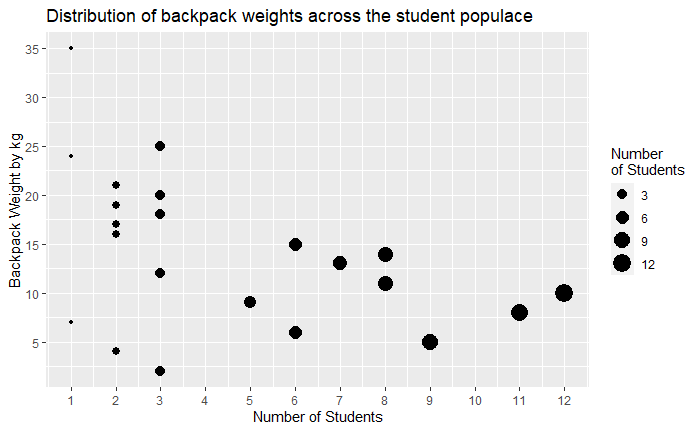

There is a varied distribution of backpack weight across all students, with the above visualization we can see that the majority of students have a backpack weight between 5 and 15kg

## Question 3

Are there differences in backpack weight between sex?

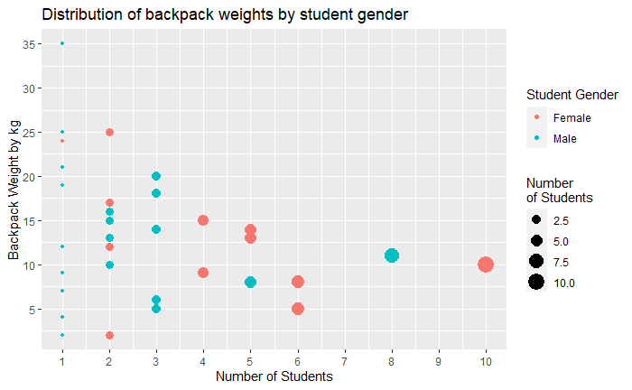

Male backpack weight is more varied, with the most number of unique weights, as well as the heaviest weight. whereas Female backpack weight tends to be similar more often.

## Question 4

What is the relationship between body weight and backpack weight?

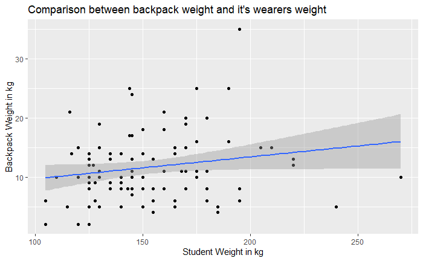

Looking at the above visualization I would not say that there was a solid relationship between body weight and backpack weight amongst the students.

## Question 5

Is this relationship different between men and women? Choose an appropriate plot and interpret your findings

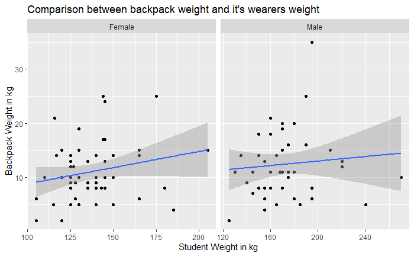

There is still no relationship between backpack weight and wearers weight, when looking at gender split there is more of a spread with females when they are compared next to males, however not enough to create a relationship.

## Question 6

What proportion of students report back pain?

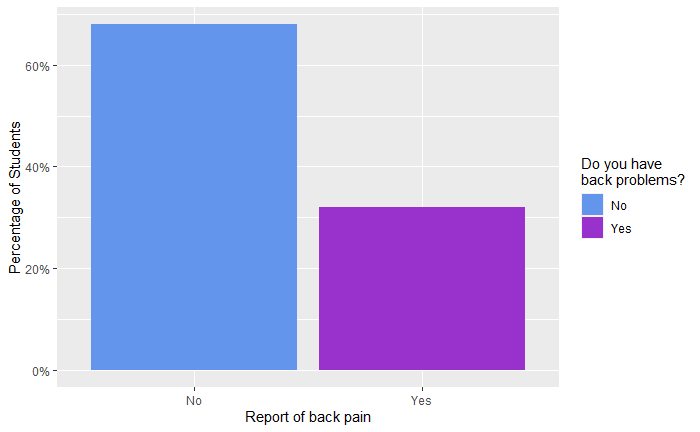

```r
# As we know there are 100 rows this should be a nice number for %
# assuming 1 = Yes and 0 = no
backpack %>%
 mutate(back_problems = ifelse(back_problems == 1, "Yes", "No")) %>%
  ggplot(aes(x = back_problems,
             y = after_stat(count/sum(count)),
             fill = back_problems))+
  geom_bar()+
  scale_y_continuous(labels = scales::percent)+
  labs(
    y = "Percentage of Students",
    x = "Report of back pain"
  ) +
  scale_fill_manual(values = c("cornflowerblue", "darkorchid"))+
  guides(fill = guide_legend(title = "Do you have \nback problems?"))
```

```r
NA
NA
```

As we can see from the above visualization, the majority of students don’t report having back issues, with the ones that do report having back problems being approx 32%

## Question 7

is this proportion different between men and women?

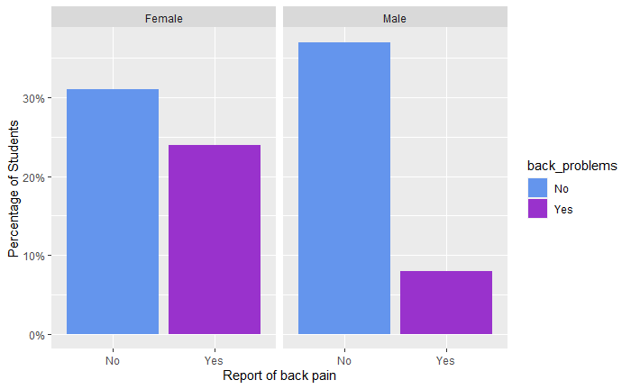

```r
backpack %>%
  mutate(back_problems = ifelse(back_problems == 1, "Yes", "No")) %>%
  ggplot(aes(x = back_problems,
             y = after_stat(count/sum(count)),
             fill = back_problems))+
  geom_bar()+
  scale_y_continuous(labels = scales::percent)+
  labs(
    y = "Percentage of Students",
    x = "Report of back pain"
  ) +
  facet_wrap(~sex)+
  scale_fill_manual(values = c("cornflowerblue", "darkorchid"))
```

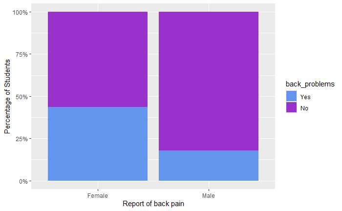

```r
# Davids changes after class notes

backpack %>%
  mutate(
    back_problems = ifelse(
      back_problems == 1, "Yes", "No"
      )
  ) %>%
  ggplot(
    aes(x = sex, fill = back_problems))+
  geom_bar(position = "fill") +
  scale_y_continuous(labels = scales::percent)+
  scale_fill_manual(values = c("Yes" =  "cornflowerblue", "No" = "darkorchid")) +
  labs(
    y = "Percentage of Students",
    x = "Report of back pain"
  )
```

As we can see, the different of reported back pain is massively different between men and women, far more women report having back pain than men. Whether they are having it and not reporting it, remains to be seen…

## Question 8

Now you’ve investigated your data separately, create plots to describe the relationship between backpack weight, body weight, gender and reported backpain.

Try both backpack_weight and body_weight as well as the ratio.

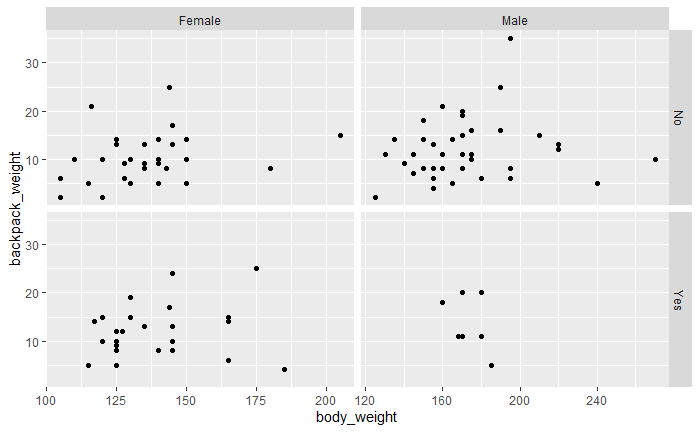

```r
# ratio is backpack_weight / body_weight
backpack %>%
  mutate(back_problems = ifelse(back_problems == 1, "Yes", "No")) %>%
  ggplot(aes(x = body_weight, y = backpack_weight, group = sex, stat = back_problems))+
  geom_point()+
  facet_grid(back_problems~sex, scales = "free_x")
```

```r
NA
NA
```

I can’t see any correlation between any of these, it is overall random…

# Extension

## Question 1

Does reported backpain differ across the year groups? Ignore year 0 in your data.

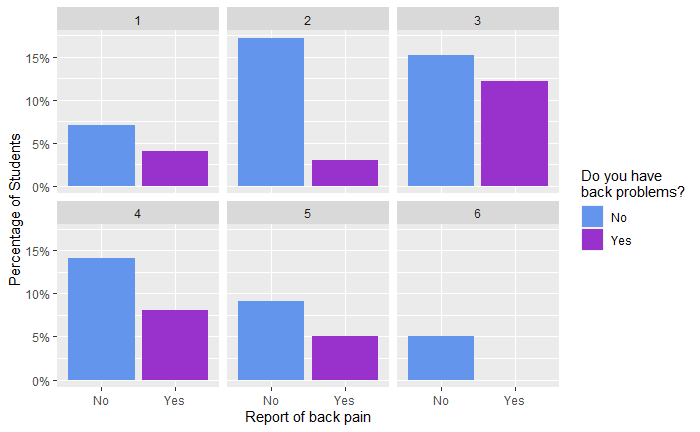

```r
backpack %>%
  mutate(back_problems = ifelse(back_problems == 1, "Yes", "No")) %>%
  filter(year != 0) %>%
  ggplot(aes(x = back_problems,
             y = after_stat(count/sum(count))))+
  geom_bar(aes(fill = back_problems))+
  scale_y_continuous(labels = scales::percent)+
  labs(
    y = "Percentage of Students",
    x = "Report of back pain"
  ) +
  scale_fill_manual(values = c("cornflowerblue", "darkorchid"))+
  guides(fill = guide_legend(title = "Do you have \nback problems?"))+
  facet_wrap(~year)
```

Reported back problems differ depending on the year, those in years 3 and 4 having the highest percentage of back problems